- **Author:** [Dace Apšvalka](https://www.mrc-cbu.cam.ac.uk/people/dace.apsvalka/) with very minor edits by [Rik Henson](https://www.mrc-cbu.cam.ac.uk/people/rik.henson/)
- **Edited:** October 2024
- **conda environment**: This uses the [mri environment](https://github.com/RikHenson/PythonNeuroimagingCourse/blob/main/mri_environment.yml)

# fMRI Data Organisation

An fMRI study typically involves multiple imaging protocols and subjects, resulting in complex datasets with numerous files in various formats, ranging from simple text files to multidimensional imaging data. These files can be organized in many ways, and without a consistent approach across projects and research groups, can arise in wasted time rearranging data or rewriting scripts to match specific file formats and structures, potentially introducing errors. Adopting a common standard for data organisation provides numerous advantages: it improves understanding of the data, even for those not directly involved in the project, reduces errors, enhances compatibility with analysis software, and facilitates the development of automated tools. In essence, it helps **make data FAIR** (Findable, Accessible, Interoperable, and Reusable).

The [Brain Imaging Data Structure (BIDS)](https://bids.neuroimaging.io/), developed since 2015, is a community-driven standard for organising data and metadata across various neuroscience modalities. Converting your fMRI project's data into BIDS format enables easier sharing, reuse, and application of automated pipelines and quality assurance protocols, such as [BIDS Apps](https://bids-apps.neuroimaging.io/) or your/your group's own pipelines.

Converting raw data into the BIDS format may initially appear challenging. While there are various conversion tools available (see a list [here](https://bids.neuroimaging.io/benefits#converters)), the range of options can make it hard to decide which tool to use. We have chosen [HeuDiConv](https://joss.theoj.org/papers/10.21105/joss.05839) which in fact predates the BIDS format and is a flexible, general-purpose converter for organising brain imaging data into structured directory layouts.

In the first part of this tutorial, we will walk you through the process of converting fMRI data into BIDS format using HeuDiConv. In the later parts, we download a dataset already in BIDS format from the OpenNeuro repository, and show you how to interact with the data using [PyBIDS](https://bids-standard.github.io/pybids/).

(*For a more detailed tutorial on BIDS conversion see: https://github.com/MRC-CBU/BIDS_conversion/tree/main/MRI.*)

Here are two recommended short videos to help you better understand the basics of fMRI terminology and data structure.

```python
from IPython.display import display, HTML

display(HTML('''
<div style="width: 1200px; margin: 0; display: flex; justify-content: space-around;">
    <div style="text-align: center;">
        <h3>fMRI Data Structure & Terminology (7 min)</h3>
        <iframe width="560" height="315" src="https://www.youtube.com/embed/OuRdQJMU5ro" frameborder="0" allow="picture-in-picture" allowfullscreen></iframe>
    </div>
    <div style="text-align: center;">
        <h3>Brain imaging data structure (11 min)</h3>
        <iframe width="560" height="315" src="https://www.youtube.com/embed/5H6XaJLp2V8" frameborder="0" allow="picture-in-picture" allowfullscreen></iframe>
    </div>
</div>
'''))
```

fMRI Data Structure & Terminology (7 min)

[video not shown]

Brain imaging data structure (11 min)

[video not shown]

**Table of contents**

1. Create a project folder
2. Creating a BIDS repository from raw (DICOM) data 2.1 Retrieving the DICOM files  
   2.2 Converting to BIDS using HeuDiConv  
   2.3.1 Step 1: Discovering your scans  
   2.3.2 Step 2: Creating a heuristic file  
   2.3.3 Step 3: Converting the data  
   2.3.4 'To Do' - additional information to check and add  
   2.4. Validate BIDS structure
3. Downloading BIDS repository from OpenNeuro
4. PyBIDS  
   4.1. Querying the BIDSLayout  
   4.2. Filtering files by entities  
   4.3. Filtering by metadata  
   4.4. Other `return_type` values  
   4.5. The `BIDSFile`  
   4.6. `.tsv` files  
   4.7. Filename parsing  
   4.8. Report generation

## Change directory and create a project folder

First you need to define the directory to where you want the data and results of these notebooks to be stored, which can do by editing the `wd` variable below:

```python
import os # python library for interacting with operating system (os)
wd = '/mnt/c/Users/rh01/PythonNeuroimagingCourse' # Linux example <-- CHANGE TO YOURS
#wd = 'C:\\Users\\rh01\\PythonNeuroimagingCourse' # or Windows example (eg if an Anaconda Temrinal)
os.chdir(wd)
```

Next we can create a directory tree for various outputs. There is no universally agreed standard, but here is a recommended folder structure for your fMRI project:

```
# ======================================================================
# Recommended directory structure for an fMRI project
# ======================================================================

# project_name
#    └── code
#        └── task
#        └── preprocessing
#        └── analysis
#    └── data
#    └── documents      # Protocols, reports, and other documentation
#    └── results        # Analysis results, figures, and summary outputs
#    └── scratch        # Temporary files and intermediate results
#    └── logs           # Log files, error reports, and processing records
```

You can create the folder structure manually or use a simple `Linux` command like this:

```
mkdir -p FaceRecognition/{code/{task,preprocessing,analysis},data,documents,results,scratch,logs}
```

We can run command-line commands directly within the notebook by adding an '!' sign at the beginning:

```python
!mkdir -p FaceRecognition/{code/{task,preprocessing,analysis},data,documents,results,scratch,logs}
!tree FaceRecognition -L 2
```

```
FaceRecognition
├── code
│   ├── analysis
│   ├── preprocessing
│   └── task
├── data
│   ├── CHANGES
│   ├── README
│   ├── acq-mprage_T1w.json
│   ├── dataset_description.json
│   ├── derivatives
│   ├── participants.json
│   ├── participants.tsv
│   ├── sub-01
│   ├── sub-02
│   ├── sub-03
│   ├── sub-04
│   ├── sub-05
│   ├── sub-06
│   ├── sub-07
│   ├── sub-08
│   ├── sub-09
│   ├── sub-10
│   ├── sub-11
│   ├── sub-12
│   ├── sub-13
│   ├── sub-14
│   ├── sub-15
│   ├── sub-16
│   └── task-facerecognition_bold.json
├── documents
├── freesurfer_license.txt
├── logs
├── results
│   └── first-level
└── scratch
    ├── joblib
    ├── preprocessing
    └── slice_timing.txt

30 directories, 9 files
```

Then we can update the current directory to this new project directory (for all future analyses):

```python
# Update working directory
wd = os.path.join(wd,'FaceRecognition')
os.chdir(wd)
print(f"Working directory currently {os.getcwd()}")
```

```
Working directory currently /mnt/c/Users/rh01/PythonNeuroimagingCourse/FaceRecognition
```

## Converting from DICOM to BIDS

If you already have MRI data in BIDS format, or want to download BIDS format data from a website, you can skip this section. If you want to run this section, you will need some DICOM data in your filespace.

Here we use the raw DICOM data from one subject of the Face Recognition dataset on OpenNeuro (same dataset for which we will load the BIDS version from OpenNeuro later).

### Retrieving the DICOM files

`DICOM` files are the raw imaging files generated by the MRI scanner. For this tutorial, we assume you have one subject's DICOM data in directory called `mridata`.

Each `Series###` folder contains DICOM files of the particular scan. The name of the folder is the same as what a radiographer named the scan in the MRI console. Usually, the name is very indicative of what type of scan it is. In the example dataset used later, for example, we acquired a T1w anatomical/structural scan (**MPRAGE**), nine functional scans (**BOLD**), and two **field maps**.

Each of these folders contains DICOM (`.dcm`) files, typically, one file per slice for structural scans or one file per volume for functional scans. These files contain a header with the metadata (e.g., acquisition parameters) and the actual image itself. DICOM is a standard format for any medical image, not just the brain. To work with the brain images, we **need to convert the DICOM files to NIfTI format** which is a cross-platform and cross-software standard for brain images. Along with having the files in NIfTI format, we need to **name and organise them according to BIDS** standard. For that, we will use HeuDiConv.

### Conversion using HeuDiConv

HeudiConv is a Python-based comand-line tool. To use it, you would either install *heudiconv* and *dcm2niix* packages locally (`pip install heudiconv dcm2niix`) or use Docker (or Apptainer/Singularity) container image (`docker pull nipy/heudiconv`).

Here we have *heudiconv* (and the required *dcm2niix*, for dicom to nifti conversion) included in the `mri` conda environment that we are using for this workshop.

HeuDiConv does the following:

- converts DICOM (.dcm) files to NIfTI format (`.nii` or `.nii.gz`);
- generates their corresponding metadata files (`.json`);
- renames the files and organises them in folders following BIDS specification;
- generates several other `.json` and `.tsv` files required for BIDS datasets.

An example of DICOM Series being converted into BIDS is:

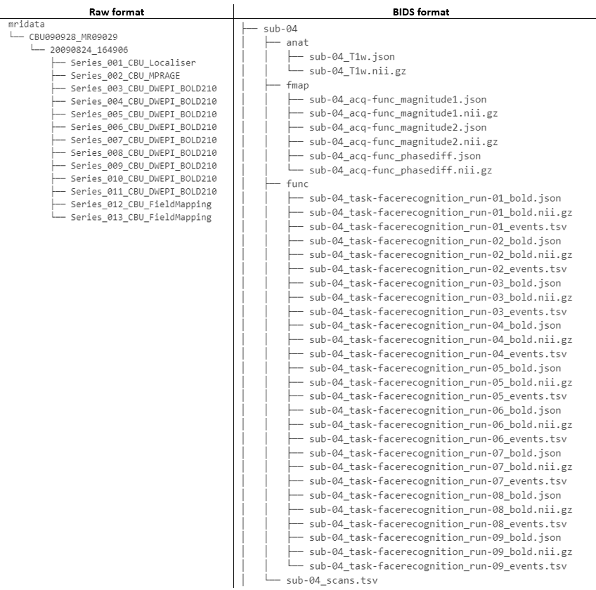

HeuDiConv needs information on how to translate your specific DICOMs into BIDS. This information is provided in a [heuristic file](https://heudiconv.readthedocs.io/en/latest/heuristics.html) that the user creates. To create the heuristic file, you need to know what scans you have, which ones you want to convert (you don't have to convert all scans, only the ones you need for your project), and how to uniquely identify each scan based on its metadata.

As such, **converting DICOM data to BIDS using HeuDiConv involves 3 main steps**:

1. Discovering what DICOM series (scans) there are in your data
2. Creating a heuristic file specifying how to translate the DICOMs into BIDS
3. Converting the data

#### Step 1: Discovering your scans

First, you need to know what scans there are in your MRI data and how to uniquely identify them using their metadata. While you could manually check the metadata of each DICOM file, this is not very convenient. Instead, you can 'ask' HeuDiConv to perform the scan discovery for you. By running HeuDiConv without specifying NIfTI conversion or a heuristic file, it will generate a DICOM info table that lists all scans and their metadata. Again, here is an example, but details depend on your DICOM server.

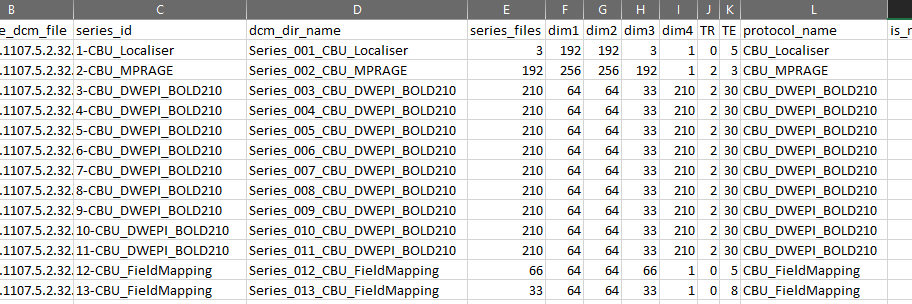

The column names are metadata fields and rows contain their corresponding values. To generate such a table, you would run the following command in the terminal:

`heudiconv --files mridata/CBU090928_MR09029/*/*/*.dcm --outdir FaceRecognition/scratch/dicom_discovery --heuristic convertall --subjects '15' --converter none --bids --overwrite`

However, command lines are error-prone and not easily reproducible. Instead, we recommend writing a simple `bash` script like this:

**Example script:**

```
#!/bin/bash

# Path to the raw DICOM files
DICOM_PATH='mridata/CBU090928_MR09029'

# Location of the output data (it will be created if it doesn't exist)
OUTPUT_PATH='scratch/dicom_discovery'

# Subject ID
SUBJECT_ID='15'

# ------------------------------------------------------------
# Run the heudiconv
# ------------------------------------------------------------
heudiconv \
    --files "${DICOM_PATH}"/*/*/*.dcm \
    --outdir "${OUTPUT_PATH}" \
    --heuristic convertall \
    --subjects "${SUBJECT_ID}" \
    --converter none \
    --bids \
    --overwrite
# ------------------------------------------------------------

# Copy the dicominfo table outside the hidden directory
cp "${OUTPUT_PATH}"/.heudiconv/"${SUBJECT_ID}"/info/dicominfo.tsv "${OUTPUT_PATH}"

# ------------------------------------------------------------

# HeudiConv parameters:
# --files: Files or directories containing files to process
# --outdir: Output directory
# --heuristic: Name of a known heuristic or path to the Python script containing heuristic
# --subjects: Subject ID
# --converter : dicom to nii converter (dcm2niix or none)
# --bids: Flag for output into BIDS structure
# --overwrite: Flag to overwrite existing files
#
# For a full list of parameters, see: https://heudiconv.readthedocs.io/en/latest/usage.html
```

After running the script, the table that we are interested in will be located at *`OUTPUT_PATH/.heudiconv/[subject ID]/info/dicominfo.tsv`*. The .heudiconv directory is a hidden directory and you might not be able to see it in your file system unless you copy it to an unhidden directory which we in fact did (notice the last line in the script).

Now, you can open the `dicominfo.tsv` file and keep it open for the next step - creating a heuristic file.

#### Step 2: Creating a heuristic file

The heuristic file must be a `Python` file. You can create and edit Python files in any text editor. You can name the file anything you want.

We need to specify the conversion template for each DICOM series. In this particular case, we want it to be in BIDS format. Therefore for each of our scan types, we need to consult BIDS specification. A good starting point is to look at the BIDS starter kit [folders](https://bids-standard.github.io/bids-starter-kit/folders_and_files/folders.html) and [filenames](https://bids-standard.github.io/bids-starter-kit/folders_and_files/files.html). (See the full BIDS specification for MRI [here](https://bids-specification.readthedocs.io/en/stable/modality-specific-files/magnetic-resonance-imaging-data.html).)

Following these guidelines, we define the template (folder structure and filenames) for our anatomical, fieldmap, and functional scans. (We don't need to worry about the BIDS-required metadata, HeuDiConv will generate the required metadata for us.)

```
# The structural/anatomical scan
    anat = create_key('sub-{subject}/ses-mri/anat/sub-{subject}_ses-mri_T1w')

    # The fieldmap scans
    fmap_mag = create_key('sub-{subject}/ses-mri/fmap/sub-{subject}_ses-mri_acq-func_magnitude')
    fmap_phase = create_key('sub-{subject}/ses-mri/fmap/sub-{subject}_ses-mri_acq-func_phasediff')

    # The functional scans
    # You need to specify the task name in the filename. It must be a single string of letters WITHOUT spaces, underscores, or dashes!
    func_task = create_key('sub-{subject}/ses-mri/func/sub-{subject}_ses-mri_task-FaceRecognition_run-{item:02d}_bold')
```

A couple of important points to note:

- We are creating a BIDS session (`ses`) called `mri`, in case there are other imaging sessions on each subject (e.g., in the OpenNeuro dataset below, there was a second `meg` session) - but if you only have one session, you can drop this sub-directory and filename part.
- For the fielmaps, we add a "key-value" pair `acq-func` to specify that these fieldmaps are intended for the functional images - to correct the functional images for susceptibility distortions. You will see how this key-value is relevant later.
- For the functional scans, you have to specify the task name. In our case, the task was *Face Recognition*. The task name must be a **single string** of letters without spaces, underscores, or dashes!
- In this example project, we had multiple functional scans with identical parameters and task names. They correspond to multiple runs of our task. Therefore we add a `run` key and its value will be added automatically as a 2-digit integer (*run-01*, *run-02* etc.).

Next, we create a dictionary `info` with our template names as keys and empty lists for their values. The values will be filled in in the next step.

```
info = {
        anat: [],
        fmap_mag: [],
        fmap_phase: [],
        func_task: []
        }
```

A `for loop` loops through all our DICOM series that are found in the `RAW_PATH` that we specify in our HeuDiConv parameters. Here we need to specify the criteria for associating DICOM series with their respective outputs. Now you need to look at the *dicominfo.tsv* table that we generated in the previous step. Again, the details will depend on your data, but in the example we will use later:

- We only have one DICOM series with *MPRAGE* in its protocol name. Therefore for the anatomical scan, we don't need to specify any additional cireteria.
- We have two fieldmaps. One of them should be a *magnitude* image and the other one a *phase* image. Both have *FieldMapping* in their protocol name therefore we need to define additional criteria to distinguish between them. They differ in the `dim3` parameter. If in doubt, ask your radiographer, but typically, the *magnitude* image has more slices (higher `dim3`).
- Our 9 functional scans are the only ones with more than one volume (`dim4`). They all are different runs of the same task, therefore we don't need any other distinguishing criteria for them, just the `dim4`. We specify here `dim4 > 100` because it could happen that not all participants and not all runs had exactly 210 volumes collected. In addition, sometimes it happens that a run is cancelled due to some problem and we want to discard any run with less than 100 volumes.

```
# Loop through all the DICOM series and assign them to the appropriate conversion key.
    for s in seqinfo:
        # Uniquelly identify each series

        # Structural
        if "MPRAGE" in s.series_id:
            info[anat].append(s.series_id)

        # Field map Magnitude (the fieldmap with the largest dim3 is the magnitude, the other is the phase)
        if 'FieldMapping' in s.series_id and s.series_files == 66:
            info[fmap_mag].append(s.series_id)

        # Field map PhaseDiff
        if 'FieldMapping' in s.series_id and s.series_files == 33:
            info[fmap_phase].append(s.series_id)

        # Functional Bold
        if s.dim4 > 100:
           info[func_task].append(s.series_id)

    # Return the dictionary
    return info
```

Finally, we add `POPULATE_INTENDED_FOR_OPTS` dictionary to our heuristic file. This will automatically add an `IntendedFor` field in the fieldmap .json files telling for which images the fieldmaps should be used to correct for susceptibility distortion. Typically, these are the functional images. There are several options how you can specify for which images the fieldmaps are intended for. See full information [here](https://heudiconv.readthedocs.io/en/latest/heuristics.html#populate-intended-for-opts). In our example, we specify to look for a `modality acquisition label`. It checks for what modality (e.g., *anat*, *func*, *dwi*) each fieldmap is intended by checking the `acq-` label in the fieldmap filename and finding corresponding modalities. For example, `acq-func` will be matched with the `func` modality. That's why when defining the template for the `fmap_mag` and `fmap_phase` we added `acq-func` in their filenames.

```
POPULATE_INTENDED_FOR_OPTS = {
    'matching_parameters': ['ModalityAcquisitionLabel'],
    'criterion': 'Closest'
}
```

Other, more advanced functions can be added to the heuristic file as well, such as input file filtering. For full information, see the [documentation](https://heudiconv.readthedocs.io/en/latest/heuristics.html).

#### Step 3: Converting the data

Once our heuristic file is created, we are ready to convert our raw DICOM data to BIDS.

To do that, we need to make three changes to the `bash` script above:

- We need to change the output path because we don't want to put this result in the *scratch* directory but in the final *data* directory
- We need to change the `--heuristic` parameter specifying the path to our newly created heuristic file
- We need to change the `--converter` parameter to `dcm2niix` because now we want the DICOM files to be converted to NIfTI format.

After making these changes, you can save the bash script to a file called "dicom_to_bids.sh" and run from the terminal:

`./code/dicom_to_bids.sh`

### 'To Do' - additional information to check and add

Once you have converted the DICOMs to BIDS, there are some details you'll need to fill in yourself to ensure the dataset is fully BIDS-compliant. HeuDiConv marks any 'missing' information with `'To Do'` placeholders.

#### Events

HeuDiConv generates the `events.tsv` file for each functional run. The files are just an empty template that you need to fill with the actual data. For tasks (i.e, not just resting state), you need to provide minimal details of *trial type*, *onset*, and *duration* for each trial in that run (though you can add other details, i.e. headers, that are specific to your experiment). This data should come from the outputs of your experimental script, so make sure your task is programmed in a way that allows you to easily retrieve the necessary trial and timing information.

For an example of a completed file, see: https://openneuro.org/datasets/ds000117/versions/1.1.0/file-display/sub-15:ses-mri:func:sub-15_ses-mri_task-facerecognition_run-01_events.tsv

#### Dataset description

The `dataset_description.json` contains details about the dataset, eg https://openneuro.org/datasets/ds000117/versions/1.1.0/file-display/dataset_description.json

#### Participants

The `participants.json` contains details about the participants (such as age and sex), eg https://openneuro.org/datasets/ds000117/versions/1.1.0/file-display/participants.tsv

#### Task information

The `task-FaceRecognition_bold.json` contains details about the task, eg https://openneuro.org/datasets/ds000117/versions/1.1.0/file-display/task-facerecognition_bold.json

#### README

Any other details about the dataset as a whole, eg https://openneuro.org/datasets/ds000117/versions/1.1.0/file-display/README

#### Validate BIDS structure

Once we have our BIDS dataset, we can use an [online BIDS validator](https://bids-standard.github.io/bids-validator/) to check if our dataset confirms with BIDS standard and what additional information we might need to include in your dataset's metadata.

## Downloading BIDS repository from OpenNeuro

For later notebooks, we are going to use the public BIDS dataset on face recognition available on [OpenNeuro as dataset "ds000117"](https://openneuro.org/datasets/ds000117)

To download the fMRI and sMRI data from this repository, we use the openneuro-py/ tool below. In fact, we use it to download the "mri" BIDS session for each of 16 subjects, which will require nearly 9 GB of diskspace. To reduce diskspace, you can delete the FLASH images in the anat directory, which we do not use in this course, which will save ~3 GB.

If you still do not have enough diskspace (ie 6 GB), you can just download sub-15, who we will use to demonstrate preprocessing, and then later you can download the statistical results for all subjects (needed for group analysis in Notebook nb05) from the `results` directory here: https://cloud.mrc-cbu.cam.ac.uk/index.php/s/3AFA0yF7QK9qIaO. The password for this cloud directory will be given by the course organiser.

(I chose sub-15 because it is the same subject used for demonstrating M/EEG and fMRI analysing using the SPM12 software package: [Henson et al., 2019](https://pubmed.ncbi.nlm.nih.gov/31068770/))

```python
import os, shutil, glob

# if want to call from the command line instead
#!openneuro-py download --dataset=ds000117 --include=sub-01/ses-mri, etc

download_flag = False # set to True if want to download, because will take a while, eg if you re-run notebook by mistake

if download_flag:
    import openneuro as on
    # could download func, fmap and each file in anat separately, without downloading dwi/FLASH,
    # but will take longer to read remote repository each time, so quicker to download all for each subject and delete unwanted stuff later

    for sub in range(1,17):
        on.download(dataset="ds000117", include=f"sub-{sub:02d}/ses-mri") # could add target-dir='data', but inserts ds000117 directory anyway?

    # If want to save diskspace by removing stuff not used below
    for sub in range(1,17):
        pth = os.path.join(wd, "ds000117", f"sub-{sub:02d}", "ses-mri")
        for rfile in glob.glob(os.path.join(pth, "anat", "*FLASH*")):
            print(f"Removing {rfile}")
            os.remove(rfile)
        # if want to remove DWI data as well, though not very big
        #dwi_pth = os.path.join(pth, "dwi")
        #if os.path.isdir(dwi_pth):
        #    shutil.rmtree(dwi_pth)
```

The downloaded data will be in a directory called `ds000117`. In rest of these notebooks, we assume BIDS data are in the `data` directory you created at the start of this notebook. Note that if you have already put any files in `data` (e.g. by following previous section on DICOM conversion), you will have to move (or delete) them first so that `data` is empty.

```python
#os.rmdir('data') # Assuming empty because just created earlier (or delete yourself)
#os.rename("ds000117","data")
```

Finally, note that you might have to copy some updates to the BIDS repository if they have not yet been uploaded to OpenNeuro, as described in the `Data` section of https://github.com/RikHenson/PythonNeuroimagingCourse/blob/main/Python_fMRI_Course_Notes.ipynb

## PyBIDS

`PyBids` is a Python module to interface with datasets conforming BIDS. See the [documentation](https://bids-standard.github.io/pybids/) and [paper](https://www.ncbi.nlm.nih.gov/pmc/articles/PMC7409983/) for more info.

**Let's explore some of the functionality of pybids.layout.** The material is adapted from https://github.com/bids-standard/pybids/tree/master/examples

```python
from bids.layout import BIDSLayout

fmri_data_dir = os.path.join(wd, "data")

# Initialize the layout
layout = BIDSLayout(fmri_data_dir)

# Print some basic information about the layout
layout
```

```
BIDS Layout: ...ingCourse/FaceRecognition/data | Subjects: 16 | Sessions: 16 | Runs: 144
```

### Querying the BIDSLayout

The main method for querying `BIDSLayout` is `.get()`.

If we call `.get()` with no additional arguments, we get back a list of all the BIDS files in our dataset.

```python
all_files = layout.get()
print("There are {} files in the layout.".format(len(all_files)))
print("\nThe first 5 files are:")
all_files[:5]
```

```
There are 567 files in the layout.

The first 5 files are:
```

```
[<BIDSJSONFile filename='/mnt/c/Users/rh01/PythonNeuroimagingCourse/FaceRecognition/data/acq-mprage_T1w.json'>,
 <BIDSFile filename='/mnt/c/Users/rh01/PythonNeuroimagingCourse/FaceRecognition/data/CHANGES'>,
 <BIDSJSONFile filename='/mnt/c/Users/rh01/PythonNeuroimagingCourse/FaceRecognition/data/dataset_description.json'>,
 <BIDSJSONFile filename='/mnt/c/Users/rh01/PythonNeuroimagingCourse/FaceRecognition/data/participants.json'>,
 <BIDSDataFile filename='/mnt/c/Users/rh01/PythonNeuroimagingCourse/FaceRecognition/data/participants.tsv'>]
```

The returned object is a list of `BIDSFile` objects.

We can also get just filenames.

```python
layout.get(return_type='filename')[:5]
```

```
['/mnt/c/Users/rh01/PythonNeuroimagingCourse/FaceRecognition/data/acq-mprage_T1w.json',
 '/mnt/c/Users/rh01/PythonNeuroimagingCourse/FaceRecognition/data/CHANGES',
 '/mnt/c/Users/rh01/PythonNeuroimagingCourse/FaceRecognition/data/dataset_description.json',
 '/mnt/c/Users/rh01/PythonNeuroimagingCourse/FaceRecognition/data/participants.json',
 '/mnt/c/Users/rh01/PythonNeuroimagingCourse/FaceRecognition/data/participants.tsv']
```

We can also get such information as

- all `subject` IDs
- all `task` names
- dataset `description`
- how many `runs` and `volumes`

```python
layout.get_subjects()
```

```
['01',
 '02',
 '03',
 '04',
 '05',
 '06',
 '07',
 '08',
 '09',
 '10',
 '11',
 '12',
 '13',
 '14',
 '15',
 '16']
```

```python
layout.get_tasks()
```

```
['facerecognition']
```

```python
layout.get_dataset_description()
```

```
{'Name': 'Multisubject, multimodal face processing',
 'License': 'CC0',
 'Authors': ['Wakeman, DG', 'Henson, RN'],
 'Acknowledgements': 'This work was supported by the UK Medical Research Council (SUAG/010\nRG91365) and Elekta Ltd. We would also like to acknowledge the contribution of Andre van der Kouwe and the A.A. Martinos Center for Biomedical Imaging (MGH) for providing the Multi-Echo FLASH sequences used i…
 'HowToAcknowledge': "Cite this paper: https://www.ncbi.nlm.nih.gov/pubmed/25977808 and consider including the following message: 'This data was obtained from the OpenNeuro database. Its accession number is ds000117'",
 'Funding': ['UK Medical Research Council (SUAG/010 RG91365), Elekta Ltd.'],
 'ReferencesAndLinks': ['https://www.ncbi.nlm.nih.gov/pubmed/25977808',
  'https://openfmri.org/dataset/ds000117/',
  'ftp://ftp.mrc-cbu.cam.ac.uk/personal/rik.henson/wakemandg_hensonrn/Publications/'],
 'BIDSVersion': '1.0.2',
 'DatasetDOI': 'doi:10.18112/openneuro.ds000117.v1.0.6'}
```

You can also convert layout to a dataframe, which might be easier to read:

```python
df = layout.to_df()
df.head()
```

| entity | path | acquisition | datatype | extension | fmap | run | session | subject | suffix | task |
| --- | --- | --- | --- | --- | --- | --- | --- | --- | --- | --- |
| 0 | /mnt/c/Users/rh01/PythonNeuroimagingCourse/Fac... | mprage | NaN | .json | NaN | NaN | NaN | NaN | T1w | NaN |
| 1 | /mnt/c/Users/rh01/PythonNeuroimagingCourse/Fac... | NaN | NaN | .json | NaN | NaN | NaN | NaN | description | NaN |
| 2 | /mnt/c/Users/rh01/PythonNeuroimagingCourse/Fac... | NaN | NaN | .json | NaN | NaN | NaN | NaN | participants | NaN |
| 3 | /mnt/c/Users/rh01/PythonNeuroimagingCourse/Fac... | NaN | NaN | .tsv | NaN | NaN | NaN | NaN | participants | NaN |
| 4 | /mnt/c/Users/rh01/PythonNeuroimagingCourse/Fac... | mprage | anat | .json | NaN | NaN | mri | 01 | T1w | NaN |

```python
TR = layout.get_tr()
print(TR)
```

```
2.0
```

Finally, with a more bit programming, we can check the number of runs per participan, and number of volumes per run. To calculate the number of volumes, we need to use the `nibabel` package (which is explained more in next Notebook) to load an image:

```python
import nibabel as nib

for sID in layout.get_subjects():
    tmp = []
    for rnum, rID in enumerate(layout.get_runs(subject = sID)):
        bold_file = layout.get(subject = sID, run = rID, extension='nii.gz', suffix='bold', return_type='filename')
        bold_image = nib.load(bold_file[0])
        tmp.append(bold_image.shape[3])
    print(f"Subject {sID}: Number of volumes per run: {tmp}")
```

```
Subject 01: Number of volumes per run: [208, 208, 208, 208, 208, 208, 208, 208, 208]
Subject 02: Number of volumes per run: [208, 208, 208, 208, 208, 208, 208, 208, 208]
Subject 03: Number of volumes per run: [208, 208, 208, 208, 208, 208, 208, 208, 208]
Subject 04: Number of volumes per run: [208, 208, 208, 208, 208, 208, 208, 208, 208]
Subject 05: Number of volumes per run: [208, 208, 208, 208, 208, 208, 208, 208, 208]
Subject 06: Number of volumes per run: [208, 208, 208, 208, 208, 208, 208, 208, 208]
Subject 07: Number of volumes per run: [208, 208, 208, 208, 208, 208, 208, 208, 208]
Subject 08: Number of volumes per run: [208, 208, 208, 208, 208, 208, 208, 208, 208]
Subject 09: Number of volumes per run: [208, 208, 208, 208, 208, 208, 208, 208, 208]
Subject 10: Number of volumes per run: [208, 208, 208, 208, 208, 208, 208, 208, 170]
Subject 11: Number of volumes per run: [208, 208, 208, 208, 208, 208, 208, 208, 208]
Subject 12: Number of volumes per run: [208, 208, 208, 208, 208, 208, 208, 208, 208]
Subject 13: Number of volumes per run: [208, 208, 208, 208, 208, 208, 208, 208, 208]
Subject 14: Number of volumes per run: [208, 208, 208, 208, 208, 208, 208, 208, 208]
Subject 15: Number of volumes per run: [208, 208, 208, 208, 208, 208, 208, 208, 208]
Subject 16: Number of volumes per run: [208, 208, 208, 208, 208, 208, 208, 208, 208]
```

You might be able to spot that one subject (`10`) had fewer volumes in their last run (e.g, due to scanner stopping). This is not a problem for later analysis, but worth knowing.

### Filtering files by entities

We can pass any BIDS-defined entities (keywords) to `.get()` method. For example, here's how we would retrieve all BOLD runs with `.nii.gz` extensions for subject `15`.

```python
# Retrieve filenames of all BOLD runs for subject
layout.get(subject='15', extension='nii.gz', suffix='bold', return_type='filename')
```

```
['/mnt/c/Users/rh01/PythonNeuroimagingCourse/FaceRecognition/data/sub-15/ses-mri/func/sub-15_ses-mri_task-facerecognition_run-01_bold.nii.gz',
 '/mnt/c/Users/rh01/PythonNeuroimagingCourse/FaceRecognition/data/sub-15/ses-mri/func/sub-15_ses-mri_task-facerecognition_run-02_bold.nii.gz',
 '/mnt/c/Users/rh01/PythonNeuroimagingCourse/FaceRecognition/data/sub-15/ses-mri/func/sub-15_ses-mri_task-facerecognition_run-03_bold.nii.gz',
 '/mnt/c/Users/rh01/PythonNeuroimagingCourse/FaceRecognition/data/sub-15/ses-mri/func/sub-15_ses-mri_task-facerecognition_run-04_bold.nii.gz',
 '/mnt/c/Users/rh01/PythonNeuroimagingCourse/FaceRecognition/data/sub-15/ses-mri/func/sub-15_ses-mri_task-facerecognition_run-05_bold.nii.gz',
 '/mnt/c/Users/rh01/PythonNeuroimagingCourse/FaceRecognition/data/sub-15/ses-mri/func/sub-15_ses-mri_task-facerecognition_run-06_bold.nii.gz',
 '/mnt/c/Users/rh01/PythonNeuroimagingCourse/FaceRecognition/data/sub-15/ses-mri/func/sub-15_ses-mri_task-facerecognition_run-07_bold.nii.gz',
 '/mnt/c/Users/rh01/PythonNeuroimagingCourse/FaceRecognition/data/sub-15/ses-mri/func/sub-15_ses-mri_task-facerecognition_run-08_bold.nii.gz',
 '/mnt/c/Users/rh01/PythonNeuroimagingCourse/FaceRecognition/data/sub-15/ses-mri/func/sub-15_ses-mri_task-facerecognition_run-09_bold.nii.gz']
```

All of the entities are found in the names of BIDS files. For example `sub-01_task-FaceRecognition_run-01_bold.nii.gz` has entities: **subject**, **task**, **run**, **suffix**, **extension**.

You can get the list of all availabe entities by `layout.get_entities()`.

Here are a few of the most common entities:

- `suffix`: The part of a BIDS filename just before the extension (e.g., 'bold', 'events', 'T1w', etc.).
- `subject`: The subject label
- `session`: The session label
- `run`: The run index
- `task`: The task name

### Filtering by metadata

Sometimes we want to search for files not just by their names, but also based on metadata defined in JSON files. We can use any key that appears in a JSON file in our project as an argument to `.get()`. This can be combined with any number of core BIDS entities (like *subject*, *run*, etc.).

For example, let's retrieve the subject's `SpacingBetweenSlices` (measured from the center of each slice to the next, in mm).

```python
layout.get_SpacingBetweenSlices(subject='15', suffix='bold')
```

```
[3.9]
```

### Other `return_type` values

We can also ask `get()` to return unique values (or IDs) of particular entities. For example, we want to know which subjects had a fieldmap acquired. We can request that information by setting `return_type='id'` - to get subject IDs. When using this option, we also need to specify a `target` entity for the ID (in this case, subject). This combination tells the `BIDSLayout` to return the unique values for the specified `target` entity.

For example, in the next example, we ask for all of the unique subject IDs that have at least one file with a `phasediff` (fieldmap) suffix.

```python
# Ask get() to return the ids of subjects that have phasediff (fieldmap_ files)
layout.get(return_type='id', target='subject', suffix='phasediff')
```

```
['01',
 '02',
 '03',
 '04',
 '05',
 '06',
 '07',
 '08',
 '09',
 '10',
 '11',
 '12',
 '13',
 '14',
 '15',
 '16']
```

If our `target` is a BIDS entity that corresponds to a particular directory in the BIDS specification (e.g., `subject` or `session`) we can also use `return_type='dir'` to get all matching subdirectories.

### The `BIDSFile`

When you call `.get()` on a `BIDSLayout`, the default returned values are objects of class `BIDSFile`. A `BIDSFile` is a lightweight container for individual files in a BIDS dataset. It provides easy access to a variety of useful attributes and methods. Let's take a closer look. First, let's pick a random file from our existing `layout`.

```python
# Pick the 7th file in the dataset
bf = layout.get(subject='15', extension='nii.gz', suffix='bold')[6]
# Print it
bf
```

```
<BIDSImageFile filename='/mnt/c/Users/rh01/PythonNeuroimagingCourse/FaceRecognition/data/sub-15/ses-mri/func/sub-15_ses-mri_task-facerecognition_run-07_bold.nii.gz'>
```

Here are some of the attributes and methods available to us in a `BIDSFile` (note that some of these are only available for certain subclasses of `BIDSFile`; e.g., you can't call `get_image()` on a `BIDSFile` that doesn't correspond to an image file!):

- `.path`: The full path of the associated file
- `.filename`: The associated file's filename (without directory)
- `.dirname`: The directory containing the file
- `.get_entities()`: Returns information about entities associated with this `BIDSFile` (optionally including metadata)
- `.get_image()`: Returns the file contents as a nibabel image (only works for image files)
- `.get_df()`: Get file contents as a pandas DataFrame (only works for TSV files)
- `.get_metadata()`: Returns a dictionary of all metadata found in associated JSON files
- `.get_associations()`: Returns a list of all files associated with this one in some way

Let's see some of these in action.

```python
# Print all the entities associated with this file, and their values
bf.get_entities()
```

```
{'datatype': 'func',
 'extension': '.nii.gz',
 'run': 07,
 'session': 'mri',
 'subject': '15',
 'suffix': 'bold',
 'task': 'facerecognition'}
```

```python
# Print first 30 metadata items associated with this file
file_metadata = bf.get_metadata()

{k: file_metadata[k] for k in list(file_metadata)[:30]}
```

```
{'AcquisitionMatrixPE': 64,
 'AcquisitionNumber': 1,
 'AcquisitionTime': '10:57:54.135000',
 'BandwidthPerPixelPhaseEncode': 30.637,
 'BaseResolution': 64,
 'BidsGuess': ['func', '_acq-epfid2_dir-AP_run-9_bold'],
 'CogAtlasID': 'http://www.cognitiveatlas.org/task/id/TODO',
 'CoilCombinationMethod': 'Sum of Squares',
 'CoilString': 'C:HEA;HEP',
 'ConversionSoftware': 'dcm2niix',
 'ConversionSoftwareVersion': 'v1.0.20240202',
 'DerivedVendorReportedEchoSpacing': 0.000510004,
 'DeviceSerialNumber': '35119',
 'DwellTime': 3.5e-06,
 'EchoTime': 0.03,
 'EffectiveEchoSpacing': 0.000510004,
 'FlipAngle': 78,
 'HeudiconvVersion': '1.1.6',
 'ImageComments': 'V',
 'ImageOrientationPatientDICOM': [0.998722,
  0.028794,
  0.041546,
  0,
  0.821902,
  -0.569629],
 'ImageOrientationText': 'Tra>Cor(-34.7)>Sag(2.9)',
 'ImageType': ['ORIGINAL', 'PRIMARY', 'M', 'ND', 'MOSAIC'],
 'ImagingFrequency': 123.251792,
 'InPlanePhaseEncodingDirectionDICOM': 'COL',
 'InstitutionAddress': 'Chaucer Road  15,Cambridge,UK,GB,CB2 2EF',
 'InstitutionName': 'MRC-CBU',
 'MRAcquisitionType': '2D',
 'MagneticFieldStrength': 3,
 'Manufacturer': 'Siemens',
 'ManufacturersModelName': 'TrioTim'}
```

`.get_image()`: Returns the file contents as a `nibabel` image (only works for image files). We can then display the image, for example, using `OrthoSlicer3D`.

**Note:** When using `orthoview()` in notebook, don't forget to close figures afterward again or use %matplotlib inline again, otherwise, you cannot plot any other figures.

```
<OrthoSlicer3D: /mnt/c/Users/rh01/PythonNeuroimagingCourse/FaceRecognition/data/sub-15/ses-mri/func/sub-15_ses-mri_task-facerecognition_run-07_bold.nii.gz (64, 64, 33, 208)>
```

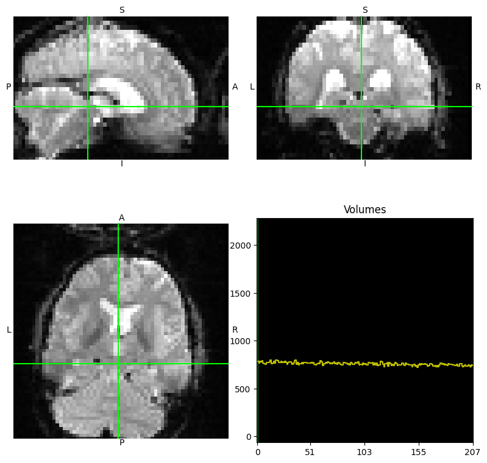

```python
%matplotlib inline

bf.get_image().orthoview()
```

### `.tsv` files

In cases where a file has a `.tsv.gz` or `.tsv` extension, it will automatically be created as a `BIDSDataFile`, and we can easily grab the contents as a `DataFrame`.

Let's look at the first `events` file from our layout.

```python
# Get the first events file
evfile = layout.get(suffix='events')[0]

# Get contents as a DataFrame and show the first few rows
df = evfile.get_df()
df.head()
```

|  | onset | duration | circle_duration | trial_type | trigger | button_pushed | response_time | stim_file |
| --- | --- | --- | --- | --- | --- | --- | --- | --- |
| 0 | 0.000 | 0.908 | 0.534 | IniFF | 5 | 4.0 | 2.158 | func/f013.bmp |
| 1 | 3.273 | 0.962 | 0.586 | ImmFF | 6 | 4.0 | 1.233 | func/f013.bmp |
| 2 | 6.647 | 0.825 | 0.546 | IniUF | 13 | 4.0 | 1.183 | func/u014.bmp |
| 3 | 9.838 | 0.968 | 0.597 | ImmUF | 14 | 4.0 | 0.930 | func/u014.bmp |
| 4 | 12.978 | 0.904 | 0.415 | IniUF | 13 | 7.0 | 1.068 | func/u016.bmp |

There are in fact 9 conditions (trial-types) in this data, which we will explain in later notebooks.

Let's look at the `participants` information.

```python
participants = layout.get(suffix='participants', extension='tsv')[0]

df = participants.get_df()
df.sort_values(by=['participant_id'])
```

|  | participant_id | age | sex | first_ses |
| --- | --- | --- | --- | --- |
| 0 | sub-01 | 31.0 | M | meg |
| 1 | sub-02 | 25.0 | M | meg |
| 2 | sub-03 | 30.0 | M | meg |
| 3 | sub-04 | 26.0 | F | meg |
| 4 | sub-05 | 23.0 | F | meg |
| 5 | sub-06 | 26.0 | M | meg |
| 6 | sub-07 | 31.0 | F | meg |
| 7 | sub-08 | 26.0 | M | meg |
| 8 | sub-09 | 29.0 | M | meg |
| 9 | sub-10 | 23.0 | M | meg |
| 10 | sub-11 | 24.0 | F | meg |
| 11 | sub-12 | 24.0 | F | meg |
| 12 | sub-13 | 25.0 | F | meg |
| 13 | sub-14 | 24.0 | F | mri |
| 14 | sub-15 | 30.0 | M | mri |
| 15 | sub-16 | 25.0 | M | mri |
| 16 | sub-emptyroom | NaN | NaN | NaN |

### Filename parsing

Let’s say you have a filename and want to manually extract BIDS entities from it. The `parse_file_entities` method provides the facility:

```python
layout.parse_file_entities('sub-15_task-facerecognition_run-07_bold.nii.gz')
```

```
{'task': 'facerecognition',
 'run': 07,
 'suffix': 'bold',
 'extension': '.nii.gz'}
```

You can do the same for `BIDSFile` object that we defined earlier.

```python
layout.parse_file_entities(bf.path)
```

```
{'subject': '15',
 'session': 'mri',
 'task': 'facerecognition',
 'run': 07,
 'suffix': 'bold',
 'datatype': 'func',
 'extension': '.nii.gz'}
```

```python
layout.parse_file_entities(bf.filename)
```

```
{'session': 'mri',
 'task': 'facerecognition',
 'run': 07,
 'suffix': 'bold',
 'extension': '.nii.gz'}
```

### Report generation

`PyBIDS` also allows you to automatically create data acquisition reports based on the available `image` and `meta-data` information. This enables a new level of standardisation and transparency. FAIR-ness, meta-analyses, etc.

```python
# import the BIDSReport function from the reports submodule
from bids.reports import BIDSReport
```

Now we only need to apply the `BIDSReport` function to our `layout` and generate our report.

```python
import warnings # just to stop warnings about
warnings.filterwarnings("ignore")

# Initialize a report for the dataset
report = BIDSReport(layout)

descriptions = report.generate() # Not sure why 6 generated?
description = descriptions.most_common()
print(description[0])
```

```
Number of patterns detected: 6
Remember to double-check everything and to replace <deg> with a degree symbol.
('In session mri, MR data were acquired using a 3-Tesla Siemens TrioTim MRI scanner.\n\tOne run of T1-weighted SP\\MP\\OSP GR\\IR (GR\\IR) single-echo structural MRI data were collected (192 slices; repetition time, TR=2250ms; echo time, TE=2.98ms; flip angle, FA=9<deg>; field of view, FOV=256x256mm…
```